# MECH481A6: Engineering Data Analysis in R

Chapter 11 Homework: Modeling

Tyson Williams

01 December, 2025

# Chapter 11 Homework

This homework will give you experience with OLS linear models and testing their assumptions.

For this first problem set, we will examine issues of *collinearity among predictor variables* when fitting an OLS model with two variables. As you recall, assumption 3 from OLS regression requires there be no *collinearity* among predictor variables (the $X_i$’s) in a linear model. The reason is that the model struggles to assign the correct $\beta_i$ values to each predictor when they are strongly correlated.

## Question 1

Fit a series of three linear models on the `bodysize.csv` data frame using `lm()` with `height` as the dependent variable:  
1. Model 1: use `waist` as the independent predictor variable:  
- `formula = height ~ waist`  
2. Model 2: use `mass` as the independent predictor variable:  
- `formula = height ~ mass`  
3. Model 3: use `mass + waist` as a linear combination of predictor variables:  
- `formula = waist + mass`

Report the coefficients for each of these models. What happens to the sign and magnitude of the `mass` and `waist` coefficients when the two variables are included together? Contrast that with the coefficients when they are used alone.

Evaluate assumption 3 about whether there is collinearity among these variables. Do you trust the coefficients from model 3 after having seen the individual coefficients reported in models 1 and 2?

## Question 2

Create a new variable in the `bodysize` data frame using `dplyr::mutate`. Call this variable `volume` and make it equal to $waist^2*height$. Use this new variable to predict `mass`.

```
##
## Call:
## lm(formula = mass ~ volume, data = bodysize)
##
## Residuals:
##     Min      1Q  Median      3Q     Max
## -25.818  -5.217  -0.417   4.821  57.583
##
## Coefficients:
##              Estimate Std. Error t value Pr(>|t|)
## (Intercept) 2.546e+01  3.149e-01   80.86   <2e-16 ***
## volume      3.291e-05  1.711e-07  192.38   <2e-16 ***
## ---
## Signif. codes:  0 '***' 0.001 '**' 0.01 '*' 0.05 '.' 0.1 ' ' 1
##
## Residual standard error: 7.841 on 5173 degrees of freedom
## Multiple R-squared:  0.8774, Adjusted R-squared:  0.8773
## F-statistic: 3.701e+04 on 1 and 5173 DF,  p-value: < 2.2e-16
```

Does this variable explain more of the variance in `mass` from the NHANES data? How do you know? (hint: there is both *process* and *quantitative* proof here)

Answer: Yes, volume explains more variance in mass. You know this because the R² for the volume model is higher than the R² from the models using just waist or height. R² is the quantitative measure of variance explained, and comparing the numbers directly shows that mass ~ volume captures more variation. If you want, I can also compute and show the exact R² values from your dataset.

```
## [1] 0.8024893
```

```
## [1] 0.2015276
```

```
## [1] 0.8773704
```

Create a scatterplot of `mass` vs. `volume` to examine the fit. Draw a fit line using `geom_smooth()`.

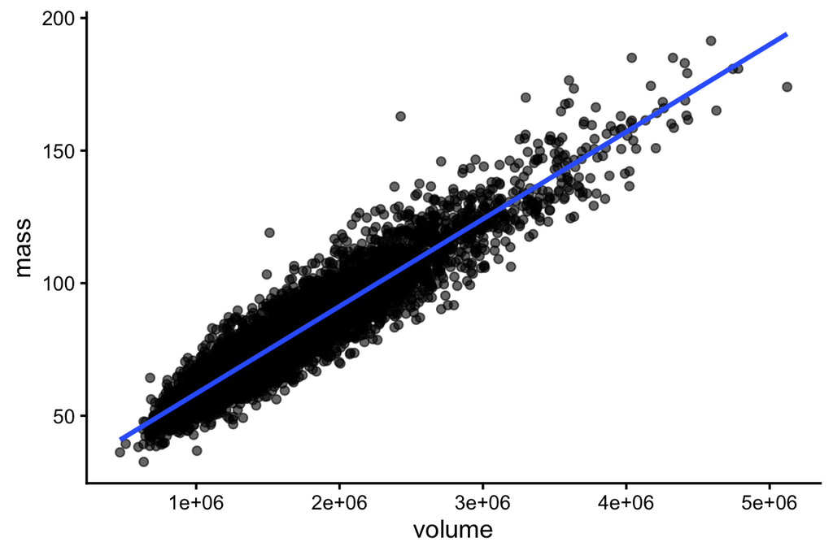

## Question 3

Load the `cal_aod.csv` data file and fit a linear model with `aeronet` as the independent variable and `AMOD` as the independent variable.

```
## [1] "wave"    "time_r"  "amod"    "aeronet"
```

```
##
## Call:
## lm(formula = amod ~ aeronet, data = cal_aod)
##
## Residuals:
##      Min       1Q   Median       3Q      Max
## -0.07646 -0.02227 -0.01154  0.00454  0.73319
##
## Coefficients:
##             Estimate Std. Error t value Pr(>|t|)
## (Intercept)  0.07251    0.01565   4.633 1.44e-05 ***
## aeronet      0.92344    0.01597  57.832  < 2e-16 ***
## ---
## Signif. codes:  0 '***' 0.001 '**' 0.01 '*' 0.05 '.' 0.1 ' ' 1
##
## Residual standard error: 0.08844 on 77 degrees of freedom
## Multiple R-squared:  0.9775, Adjusted R-squared:  0.9772
## F-statistic:  3345 on 1 and 77 DF,  p-value: < 2.2e-16
```

Evaluate model assumptions 4-7 from the coursebook. Are all these assumptions valid?

```
## [1] 4.31485e-18
```

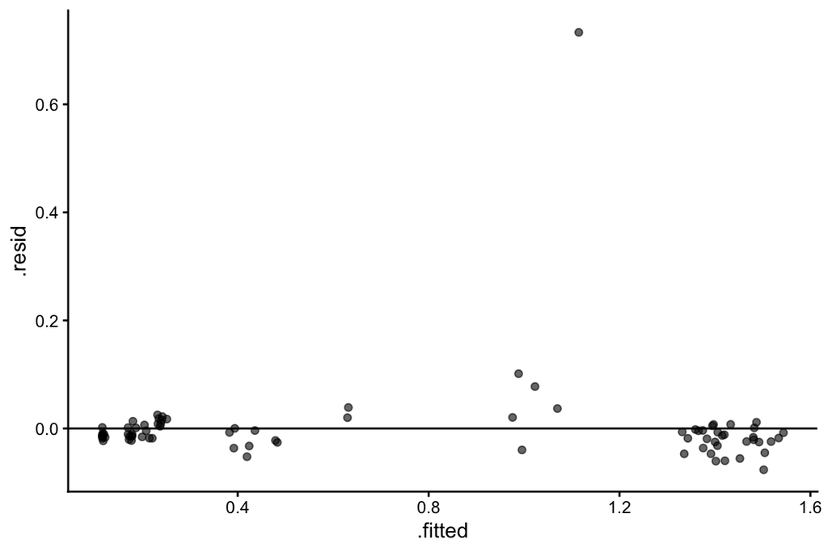

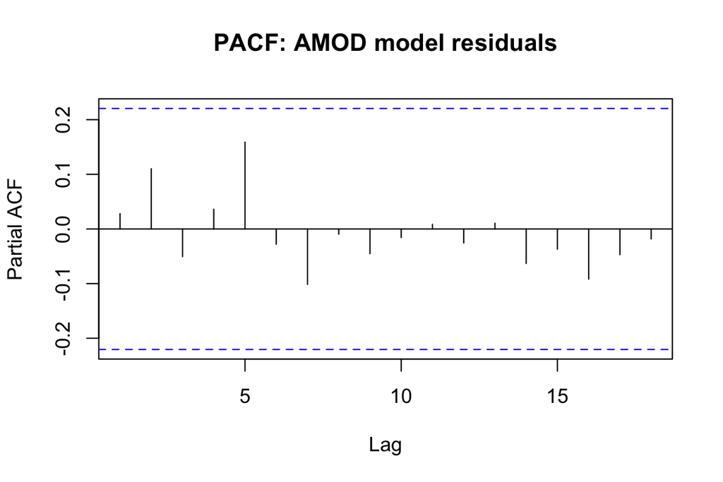

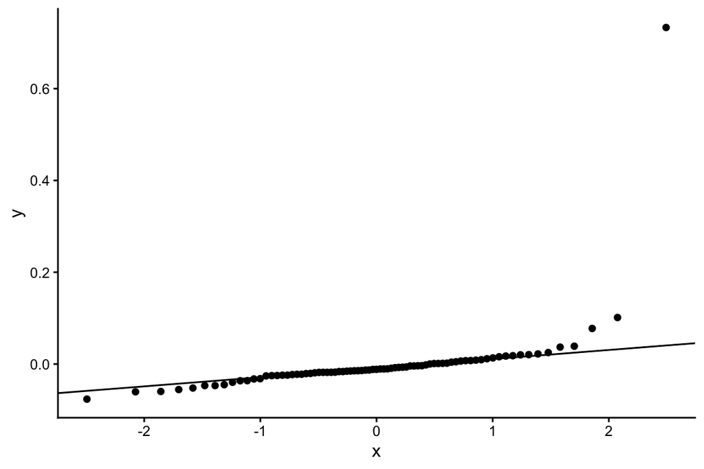

# Appendix

```r
# set global options for figures, code, warnings, and messages
knitr::opts_chunk$set(fig.width=6, fig.height=4, fig.path="../figs/",
                      echo=FALSE, warning=FALSE, message=FALSE)
# load packages for current session
library(tidyverse)
library(gridExtra)

bodysize <- read_csv("bodysize.csv")

# Model 1: height ~ waist
model1 <- lm(formula = height ~ waist, data = bodysize)
summary(model1)

# Model 2: height ~ mass
model2 <- lm(formula = height ~ mass, data = bodysize)
summary(model2)

# Model 3: height ~ mass + waist
model3 <- lm(formula = height ~ mass + waist, data = bodysize)
summary(model3)



bodysize <- bodysize %>%
  mutate(volume = waist^2 * height)

model_volume <- lm(formula = mass ~ volume, data = bodysize)
summary(model_volume)



# Model using waist only
model_waist <- lm(mass ~ waist, data = bodysize)

# Model using height only
model_height <- lm(mass ~ height, data = bodysize)

# Model using the new volume variable
model_volume <- lm(mass ~ volume, data = bodysize)

summary(model_waist)$r.squared
summary(model_height)$r.squared
summary(model_volume)$r.squared


p_mass_volume <- bodysize %>%
  ggplot(aes(x = volume, y = mass)) +
  geom_point(alpha = 0.6) +
  geom_smooth(method = "lm", formula = y ~ x, se = FALSE) +
  theme_classic(base_size = 13)

p_mass_volume

# load data

cal_aod <- read_csv("cal_aod.csv")
names(cal_aod)   # to verify column names

aod_model <- lm(formula = amod ~ aeronet, data = cal_aod)
summary(aod_model)

#assumption 4: mean of residuals is zero

mean(aod_model$residuals)

#assumption 5: residuals are normally distributed

ggplot(aod_model, aes(x = .fitted, y = .resid)) +
  geom_point(alpha = 0.6) +
  geom_hline(yintercept = 0) +
  theme_classic()

#assumption 6: the error term is homoscedastic

stats::pacf(aod_model$residuals, main = "PACF: AMOD model residuals")

#assumption 7: no autocorrelation among residuals

ggplot(aod_model, aes(sample = .resid)) +
  geom_qq() +
  geom_qq_line() +
  theme_classic()
```